# Meta-analysis physiological costs of hibernation: Report 1 - OS Hibernation

Pablo Capilla-Lasheras

2026-05-22

This [R Markdown](http://rmarkdown.rstudio.com) Notebook contains the initial meta-analysis for the project ‘physiological ’costs’ of hibernation. Specifically, the meta-analysis of hibernation

## Dataset and calculation of effect sizes

The dataset for this meta-analysis has been collected from the literature and curated by Pablo Burraco, Marko Prokic and Tamara Petrovic. It contains data on physiological effects of hibernation in different systems. Here a quick snapshot of the first lines of the dataset:

```r
# dataset with raw data
data <- openxlsx::read.xlsx(
  here(
    "./01_data/raw_data/Burraco_et_al_hibernation_hibernation.xlsx"
  ),
  colNames = T,
  sheet = 1
)

paged_table(data, options = list(rows.print = 20))
```

|  | Reference | Year | StudyID | Species | Thermoregulation | Class | Ver_Invert | Experiment_venue | Tissue | Biomarker_cat_2 | Specific_biomarker | Unit | Euthermia_N | Euthermia_M | Euthermia_SD | Euthermia_SE | Hib_N | Hib_M | Hib_SD | Hib_SE |
| --- | --- | --- | --- | --- | --- | --- | --- | --- | --- | --- | --- | --- | --- | --- | --- | --- | --- | --- | --- | --- |
| 1 | Allan and Storey, 2012 | 2012 | study125 | Ictidomys_tridecemlineatus | Endothermic | Mammalia | Vertebrate | Laboratory | muscle | Antioxidant | Heme_Oxygenase_1 | relative_expression_level | 4 | 9.901800e-01 | NA | 1.178800e-01 | 4 | 6.070700e-01 | NA | 1.296700e-01 |
| 2 | Allan and Storey, 2012 | 2012 | study125 | Ictidomys_tridecemlineatus | Endothermic | Mammalia | Vertebrate | Laboratory | muscle | Antioxidant | Heme_Oxygenase_1 | relative_expression_level | 4 | 9.901800e-01 | NA | 1.178800e-01 | 4 | 4.833000e-01 | NA | 9.430000e-02 |
| 3 | Allan and Storey, 2012 | 2012 | study125 | Ictidomys_tridecemlineatus | Endothermic | Mammalia | Vertebrate | Laboratory | muscle | Antioxidant | Heme_Oxygenase_1 | relative_expression_level | 4 | 9.901800e-01 | NA | 1.178800e-01 | 4 | 4.538300e-01 | NA | 5.894000e-02 |
| 4 | Allan and Storey, 2012 | 2012 | study125 | Ictidomys_tridecemlineatus | Endothermic | Mammalia | Vertebrate | Laboratory | muscle | Antioxidant | MnSOD | relative_expression_level | 4 | 9.960700e-01 | NA | 4.715000e-02 | 4 | 2.174850e+00 | NA | 2.004000e-01 |
| 5 | Allan and Storey, 2012 | 2012 | study125 | Ictidomys_tridecemlineatus | Endothermic | Mammalia | Vertebrate | Laboratory | muscle | Antioxidant | MnSOD | relative_expression_level | 4 | 9.960700e-01 | NA | 4.715000e-02 | 4 | 1.956780e+00 | NA | 1.827100e-01 |
| 6 | Allan and Storey, 2012 | 2012 | study125 | Ictidomys_tridecemlineatus | Endothermic | Mammalia | Vertebrate | Laboratory | muscle | Antioxidant | MnSOD | relative_expression_level | 4 | 9.960700e-01 | NA | 4.715000e-02 | 4 | 1.060900e+00 | NA | 1.591400e-01 |
| 7 | Allan and Storey, 2012 | 2012 | study125 | Ictidomys_tridecemlineatus | Endothermic | Mammalia | Vertebrate | Laboratory | muscle | Regulatory | NFkB_p50 | relative_expression_level | 4 | 9.950100e-01 | NA | 1.122200e-01 | 4 | 1.406480e+00 | NA | 2.094800e-01 |
| 8 | Allan and Storey, 2012 | 2012 | study125 | Ictidomys_tridecemlineatus | Endothermic | Mammalia | Vertebrate | Laboratory | muscle | Regulatory | NFkB_p50 | relative_expression_level | 4 | 9.950100e-01 | NA | 1.122200e-01 | 4 | 2.274310e+00 | NA | 1.870400e-01 |
| 9 | Allan and Storey, 2012 | 2012 | study125 | Ictidomys_tridecemlineatus | Endothermic | Mammalia | Vertebrate | Laboratory | muscle | Regulatory | NFkB_p50 | relative_expression_level | 4 | 9.950100e-01 | NA | 1.122200e-01 | 4 | 1.129680e+00 | NA | 1.271800e-01 |
| 10 | Allan and Storey, 2012 | 2012 | study125 | Ictidomys_tridecemlineatus | Endothermic | Mammalia | Vertebrate | Laboratory | muscle | Regulatory | NFkB_p65 | relative_expression_level | 4 | 9.950100e-01 | NA | 7.482000e-02 | 4 | 1.384040e+00 | NA | 5.985000e-02 |

[output cut: 909 more lines]

As a summary of the *initial dataset*:

- Number of studies: 60
- Number of species: 28

For this initial meta-analysis, I am going to include all oxidative stress (OS) markers and calculate the standarised mean difference (g; with heteroscedastic population variances) as the effect size of analysis comparing **hibernation** *versus* **euthermia**. Positive SMD values indicate higher OS values in *hibernation* while negative SMD indicate lower OS values in hibernation. This is a summary of the effect size calculation based on the dataset above:

```r
# ES data
data <- readRDS(
  here(
    "./01_data/processed_RDS_data_files/01_OS_metaanalysis_hibernation_full_data.RDS"
  )
)
data$obsID <- 1:nrow(data) # observation ID

# handling species names for phylogenetic-controlled models
data$Species <- replace_values(
  data$Species,
  "Myotis_pilosus" ~ "Myotis_ricketti" # correcting synomyn names manuallty
)

data$scientific_name <- gsub(
  x = data$Species,
  pattern = "_",
  replacement = " "
)

data$scientific_name_phylo <- data$scientific_name

## data for SMD
df_SMD <- data %>%
  filter(!is.na(SMDH)) %>%
  filter(!is.na(SMDH.sv))

# matrix with phylogentic correlations
phylo_cor <- readRDS(
  here(
    "./01_data/processed_RDS_data_files/01_OS_phylogenetic_correlations_hibernation.RDS"
  )
)

phylo_tree <- readRDS(
  here(
    "./01_data/processed_RDS_data_files/01_OS_phylogenetic_tree_hibernation.RDS"
  )
)

tree <- ggtree(phylo_tree, size = 1.2) +
  xlim_tree(c(0, 35)) +
  geom_tiplab(
    aes(
      label = paste0(
        "italic('",
        sub(x = label, pattern = "_", replacement = " "),
        "')"
      )
    ),
    parse = TRUE,
    offset = 0.5,
    size = 5,
    hjust = 0
  )

ggsave(
  filename = here(
    "./03_plots/01_hibernation/00a_OS_phylo_tree.png"
  ),
  plot = tree,
  device = "png",
  height = 150,
  width = 90,
  units = "mm"
)

ggsave(
  filename = here(
    "./03_plots/01_hibernation/00a_OS_phylo_tree.pdf"
  ),
  plot = tree,
  height = 150,
  width = 90,
  units = "mm"
)
```

Summary of SMD effect size and number of observations included in the meta-analysis:

```r
summary(df_SMD$SMDH)
```

```
##      Min.   1st Qu.    Median      Mean   3rd Qu.      Max.
## -13.79044  -0.91954   0.04767   0.03417   0.93321  12.91844
```

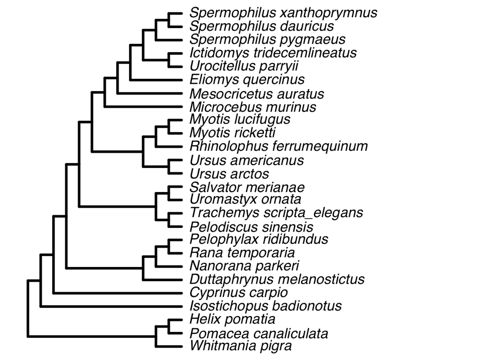

```r
print(tree)
```

- Number of observation with non-missing SMD: 742
- Number of studies in the dataset for analysis: 53
- Number of species in the dataset for analysis: 26

## Initial meta-analysis:

This initial model contains only the intercept and four random effects to account for phylogenetic variation and variation between and within studies beyond sampling variance.

```r
## calculate var-cover matrix to control for correlated effect sizes within study and tissue
V <- vcalc(
  vi = SMDH.sv,
  cluster = StudyID,
  subgroup = Tissue,
  grp1 = Hib_M,
  grp2 = Euthermia_M,
  w1 = Hib_N,
  w2 = Euthermia_N,
  data = df_SMD
)

# model
model_SMD <- rma.mv(
  yi = SMDH,
  V = V,
  mods = ~1,
  random = list(
    ~ 1 | scientific_name_phylo,
    ~ 1 | Species,
    ~ 1 | obsID,
    ~ 1 | StudyID
  ),
  data = df_SMD,
  R = list(scientific_name_phylo = phylo_cor),
  method = "REML",
  control = list(optimizer = "BFGS"),
  verbose = F
)
```

```r
saveRDS(
  object = model_SMD,
  file = here(
    './04_models/01_hibernation/01a_metamodel_hibernation_OS.RDS'
  )
)
model_SMD <- readRDS(
  file = here(
    './04_models/01_hibernation/01a_metamodel_hibernation_OS.RDS'
  )
)
summary(model_SMD)
```

```
##
## Multivariate Meta-Analysis Model (k = 733; method: REML)
##
##     logLik    Deviance         AIC         BIC        AICc
## -1343.8436   2687.6872   2697.6872   2720.6661   2697.7699
##
## Variance Components:
##
##             estim    sqrt  nlvls  fixed                 factor    R
## sigma^2.1  0.0759  0.2755     26     no  scientific_name_phylo  yes
## sigma^2.2  0.1754  0.4188     26     no                Species   no
## sigma^2.3  1.1235  1.0600    733     no                  obsID   no
## sigma^2.4  0.0000  0.0051     53     no                StudyID   no
##
## Test for Heterogeneity:
## Q(df = 732) = 2704.4426, p-val < .0001
##
## Model Results:
##
## estimate      se     zval    pval    ci.lb   ci.ub
##  -0.1330  0.1864  -0.7131  0.4758  -0.4984  0.2325
##
## ---
## Signif. codes:  0 '***' 0.001 '**' 0.01 '*' 0.05 '.' 0.1 ' ' 1
```

```r
i2_SMD <- round(i2_ml(model_SMD), digits = 4) # heterogeneity random effects
```

Proportion of variation left after accounting for sampling variance and proportion accounted by each random effect:

```r
knitr::kable(
  x = data.frame(
    Variable = names(i2_SMD),
    i2_value_percentage = as.numeric(round(i2_SMD, digits = 3))
  )
) %>%
  kableExtra::kable_styling(full_width = F)
```

| Variable | i2_value_percentage |
| --- | --- |
| I2_Total | 76.741 |
| I2_scientific_name_phylo | 4.236 |
| I2_Species | 9.789 |
| I2_obsID | 62.715 |
| I2_StudyID | 0.002 |

### Plot of results of intercept-only model:

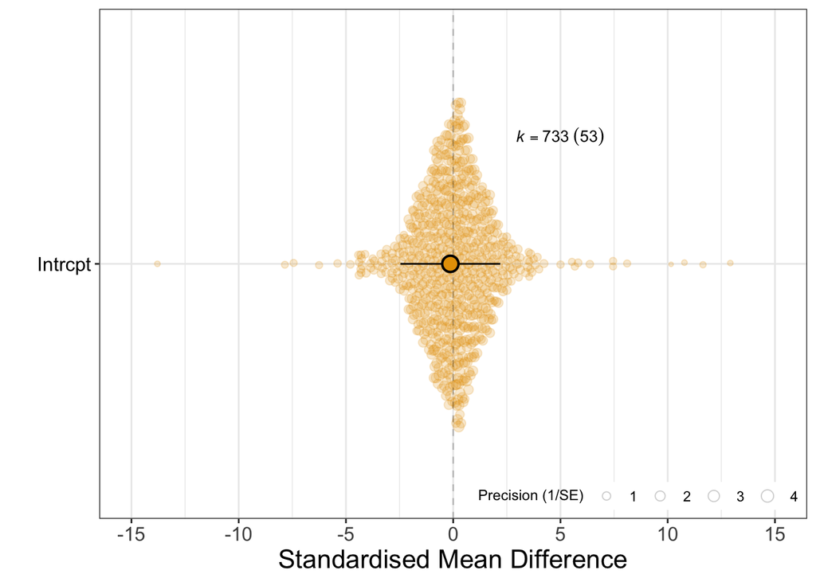

```r
overall_plot <- orchard_plot(
  object = model_SMD,
  mod = "1",
  group = 'StudyID',
  k.pos = 5,
  trunk.size = 1,
  alpha = 0.2,
  cb = FALSE,
  xlab = "Standardised Mean Difference",
  transfm = "none"
) +
  scale_fill_okabe_ito() +
  scale_color_okabe_ito() +
  theme(
    axis.text = element_text(size = 12),
    axis.text.y = element_text(size = 12, angle = 0),
    axis.title = element_text(size = 16)
  ) +
  scale_y_continuous(
    limits = c(-15, 15),
    breaks = seq(-15, 15, 5),
    label = seq(-15, 15, 5)
  )

overall_plot
```

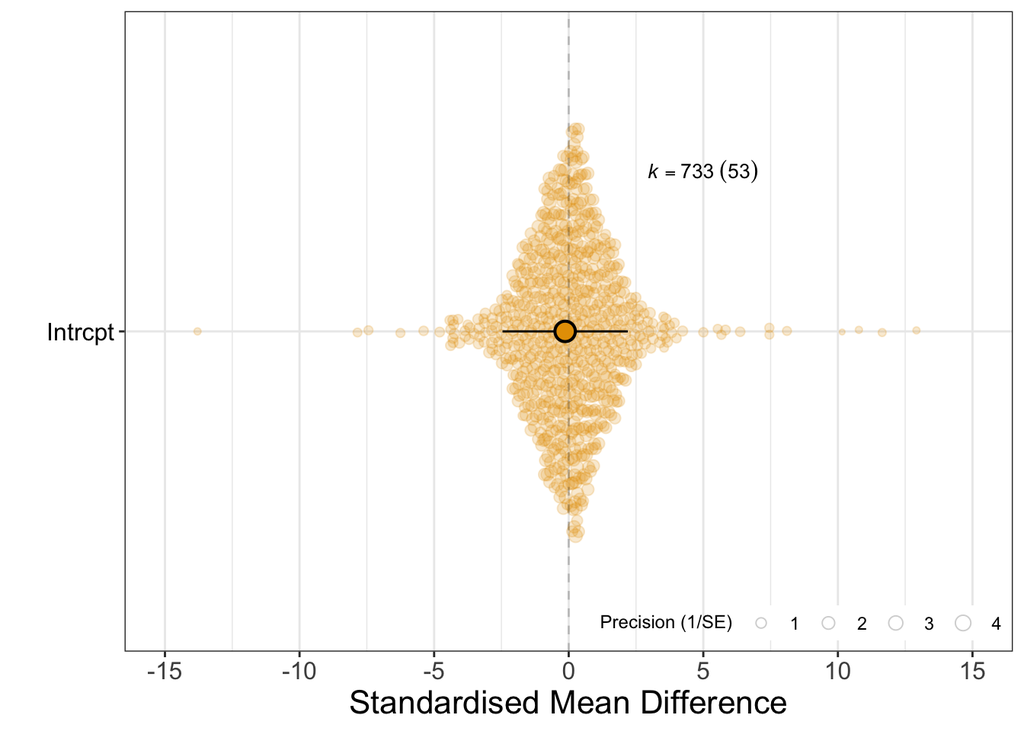

```r
ggsave(
  filename = here(
    "./03_plots/01_hibernation/01a_overall_plot_hibernation_OS.png"
  ),
  plot = overall_plot,
  device = "png",
  height = 110,
  width = 185,
  units = "mm"
)

ggsave(
  filename = here(
    "./03_plots/01_hibernation/01a_overall_plot_hibernation_OS.pdf"
  ),
  plot = overall_plot,
  height = 110,
  width = 185,
  units = "mm"
)

overall_plot
```

### Publication bias: small-study effects

```r
df_SMD$inv_eff_ss <- (1 / df_SMD$Hib_N) + (1 / df_SMD$Euthermia_N)

model_SMD_pb <- rma.mv(
  yi = SMDH,
  V = V,
  mods = ~ 1 + sqrt(inv_eff_ss),
  random = list(
    ~ 1 | scientific_name_phylo,
    ~ 1 | Species,
    ~ 1 | obsID,
    ~ 1 | StudyID
  ),
  data = df_SMD,
  R = list(scientific_name_phylo = phylo_cor),
  method = "REML",
  control = list(optimizer = "BFGS"),
  verbose = F
)
```

```r
saveRDS(
  object = model_SMD_pb,
  file = here(
    './04_models/01_hibernation/06a_pb_metamodel_hibernation_OS.RDS'
  )
)
model_SMD_pb <- readRDS(
  file = here(
    './04_models/01_hibernation/06a_pb_metamodel_hibernation_OS.RDS'
  )
)

summary(model_SMD_pb)
```

```
##
## Multivariate Meta-Analysis Model (k = 733; method: REML)
##
##     logLik    Deviance         AIC         BIC        AICc
## -1341.9798   2683.9595   2695.9595   2723.5260   2696.0756
##
## Variance Components:
##
##             estim    sqrt  nlvls  fixed                 factor    R
## sigma^2.1  0.0605  0.2459     26     no  scientific_name_phylo  yes
## sigma^2.2  0.1901  0.4360     26     no                Species   no
## sigma^2.3  1.1258  1.0610    733     no                  obsID   no
## sigma^2.4  0.0000  0.0062     53     no                StudyID   no
##
## Test for Residual Heterogeneity:
## QE(df = 731) = 2704.4250, p-val < .0001
##
## Test of Moderators (coefficient 2):
## QM(df = 1) = 0.5685, p-val = 0.4509
##
## Model Results:
##
##                   estimate      se     zval    pval    ci.lb   ci.ub
## intrcpt            -0.4595  0.4582  -1.0029  0.3159  -1.3575  0.4385
## sqrt(inv_eff_ss)    0.5616  0.7449   0.7540  0.4509  -0.8983  2.0215
##
## ---
## Signif. codes:  0 '***' 0.001 '**' 0.01 '*' 0.05 '.' 0.1 ' ' 1
```

### Publication bias: time-lag effects

```r
df_SMD$year_scl <- scale(df_SMD$Year)

model_SMD_tl <- rma.mv(
  yi = SMDH,
  V = V,
  mods = ~ 1 + year_scl,
  random = list(
    ~ 1 | scientific_name_phylo,
    ~ 1 | Species,
    ~ 1 | obsID,
    ~ 1 | StudyID
  ),
  data = df_SMD,
  R = list(scientific_name_phylo = phylo_cor),
  method = "REML",
  control = list(optimizer = "BFGS"),
  verbose = F
)
```

```r
saveRDS(
  object = model_SMD_tl,
  file = here(
    './04_models/01_hibernation/07a_timelag_metamodel_hibernation_OS.RDS'
  )
)
model_SMD_tl <- readRDS(
  file = here(
    './04_models/01_hibernation/07a_timelag_metamodel_hibernation_OS.RDS'
  )
)

summary(model_SMD_tl)
```

```
##
## Multivariate Meta-Analysis Model (k = 733; method: REML)
##
##     logLik    Deviance         AIC         BIC        AICc
## -1339.7964   2679.5928   2691.5928   2719.1593   2691.7088
##
## Variance Components:
##
##             estim    sqrt  nlvls  fixed                 factor    R
## sigma^2.1  0.0829  0.2880     26     no  scientific_name_phylo  yes
## sigma^2.2  0.1111  0.3333     26     no                Species   no
## sigma^2.3  1.1235  1.0600    733     no                  obsID   no
## sigma^2.4  0.0000  0.0042     53     no                StudyID   no
##
## Test for Residual Heterogeneity:
## QE(df = 731) = 2627.4274, p-val < .0001
##
## Test of Moderators (coefficient 2):
## QM(df = 1) = 5.4868, p-val = 0.0192
##
## Model Results:
##
##           estimate      se     zval    pval    ci.lb   ci.ub
## intrcpt    -0.0936  0.1829  -0.5118  0.6088  -0.4522  0.2649
## year_scl    0.1843  0.0787   2.3424  0.0192   0.0301  0.3386  *
##
## ---
## Signif. codes:  0 '***' 0.001 '**' 0.01 '*' 0.05 '.' 0.1 ' ' 1
```

The results above suggest some degree of time-lag bias.

```r
results <- mod_results(model_SMD_tl, mod = "year_scl", group = "StudyID")
time_bias <- orchaRd::bubble_plot(
  model_SMD_tl,
  mod = 'year_scl',
  group = 'StudyID',
  alpha = 0.2,
  cb = FALSE,
  xlab = "Year of publication (scaled)",
  transfm = "none",
) +
  theme(
    axis.text = element_text(size = 12),
    axis.text.y = element_text(size = 12, angle = 0),
    axis.title = element_text(size = 16)
  )

ggsave(
  filename = here(
    "./03_plots/01_hibernation/06a_overall_plot_hibernation_OS.png"
  ),
  device = 'png',
  plot = time_bias,
  height = 110,
  width = 185,
  units = "mm"
)
ggsave(
  filename = here(
    "./03_plots/01_hibernation/06a_overall_plot_hibernation_OS.pdf"
  ),
  plot = time_bias,
  height = 110,
  width = 185,
  units = "mm"
)
```

## Meta-analysis with all organisms but including different OS markers:

Number of observations for each type:

```r
table(df_SMD$Biomarker_cat_2)
```

```
##
##      Antioxidant Oxidative_damage       Regulatory              ROS
##              582              102               34               24
```

```r
model_SMD_biomarker <- rma.mv(
  yi = SMDH,
  V = V,
  mods = ~ Biomarker_cat_2 - 1,
  random = list(
    ~ 1 | scientific_name_phylo,
    ~ 1 | Species,
    ~ 1 | obsID,
    ~ 1 | StudyID
  ),
  data = df_SMD,
  R = list(scientific_name_phylo = phylo_cor),
  method = "REML",
  control = list(optimizer = "BFGS"),
  verbose = F
)
```

```r
saveRDS(
  object = model_SMD_biomarker,
  file = here(
    './04_models/01_hibernation/02a_metareg_biomarker_hibernation_OS.RDS'
  )
)
model_SMD_biomarker <- readRDS(
  file = here(
    './04_models/01_hibernation/02a_metareg_biomarker_hibernation_OS.RDS'
  )
)
summary(model_SMD_biomarker)
```

```
##
## Multivariate Meta-Analysis Model (k = 733; method: REML)
##
##     logLik    Deviance         AIC         BIC        AICc
## -1331.1715   2662.3429   2678.3429   2715.0763   2678.5429
##
## Variance Components:
##
##             estim    sqrt  nlvls  fixed                 factor    R
## sigma^2.1  0.0644  0.2537     26     no  scientific_name_phylo  yes
## sigma^2.2  0.1871  0.4325     26     no                Species   no
## sigma^2.3  1.1009  1.0492    733     no                  obsID   no
## sigma^2.4  0.0000  0.0045     53     no                StudyID   no
##
## Test for Residual Heterogeneity:
## QE(df = 729) = 2680.0408, p-val < .0001
##
## Test of Moderators (coefficients 1:4):
## QM(df = 4) = 18.5459, p-val = 0.0010
##
## Model Results:
##
##                                  estimate      se     zval    pval    ci.lb
## Biomarker_cat_2Antioxidant        -0.2293  0.1809  -1.2676  0.2049  -0.5840
## Biomarker_cat_2Oxidative_damage    0.2355  0.2156   1.0923  0.2747  -0.1870
## Biomarker_cat_2Regulatory          0.4782  0.3180   1.5039  0.1326  -0.1450
## Biomarker_cat_2ROS                -0.4694  0.3188  -1.4726  0.1409  -1.0942
##                                   ci.ub
## Biomarker_cat_2Antioxidant       0.1253
## Biomarker_cat_2Oxidative_damage  0.6580
## Biomarker_cat_2Regulatory        1.1014
## Biomarker_cat_2ROS               0.1554
##
## ---
## Signif. codes:  0 '***' 0.001 '**' 0.01 '*' 0.05 '.' 0.1 ' ' 1
```

### Plot of results of biomarker meta-regression:

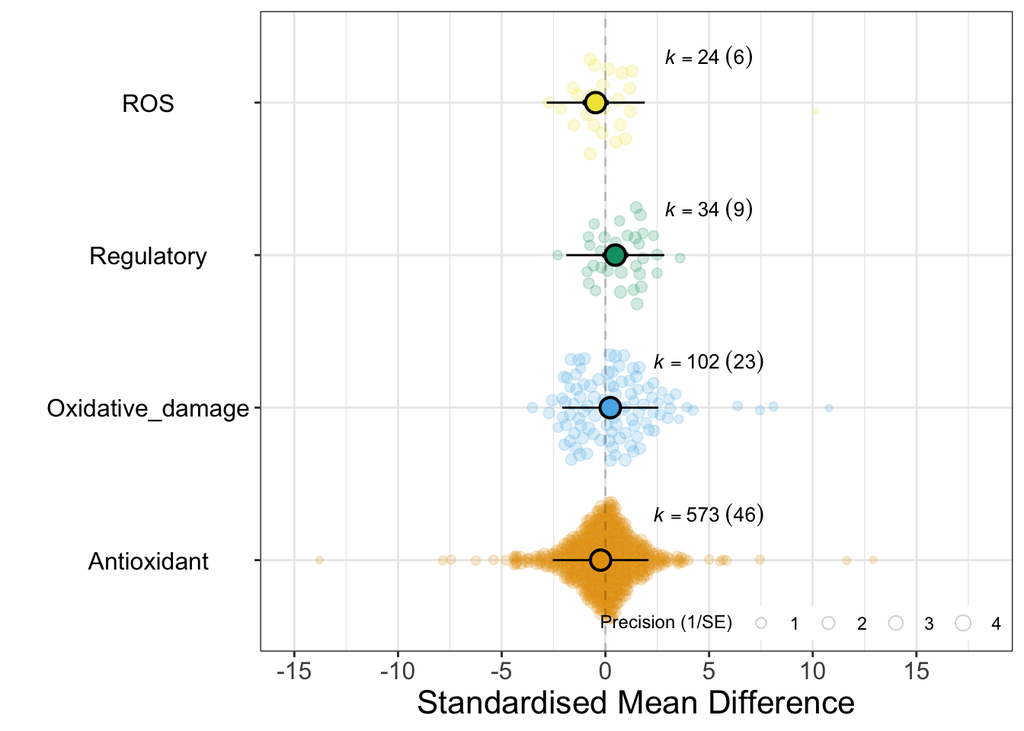

```r
biomarker_plot <- orchard_plot(
  object = model_SMD_biomarker,
  mod = 'Biomarker_cat_2',
  group = 'StudyID',
  k.pos = 5,
  trunk.size = 1,
  alpha = 0.2,
  cb = FALSE,
  xlab = "Standardised Mean Difference",
  transfm = "none"
) +
  scale_fill_okabe_ito() +
  scale_color_okabe_ito() +
  theme(
    axis.text = element_text(size = 12),
    axis.text.y = element_text(size = 12, angle = 0),
    axis.title = element_text(size = 16)
  ) +
  scale_y_continuous(
    limits = c(-15, 18),
    breaks = seq(-15, 15, 5),
    label = seq(-15, 15, 5)
  )

ggsave(
  filename = here(
    "./03_plots/01_hibernation/02a_biomarker_OS.png"
  ),
  plot = biomarker_plot,
  device = "png",
  height = 110,
  width = 185,
  units = "mm"
)

ggsave(
  filename = here(
    "./03_plots/01_hibernation/02a_biomarker_OS.pdf"
  ),
  plot = biomarker_plot,
  height = 110,
  width = 185,
  units = "mm"
)

biomarker_plot
```

## Meta-analysis including thermoregulation type as a moderator:

Number of observations for each type:

```r
table(df_SMD$Thermoregulation)
```

```
##
## Ectothermic Endothermic
##         299         443
```

```r
model_SMD_thermoregulation <- rma.mv(
  yi = SMDH,
  V = V,
  mods = ~ Thermoregulation - 1,
  random = list(
    ~ 1 | scientific_name_phylo,
    ~ 1 | Species,
    ~ 1 | obsID,
    ~ 1 | StudyID
  ),
  data = df_SMD,
  R = list(scientific_name_phylo = phylo_cor),
  method = "REML",
  control = list(optimizer = "BFGS"),
  verbose = F
)
```

```r
saveRDS(
  object = model_SMD_thermoregulation,
  file = here(
    './04_models/01_hibernation/03a_metareg_thermoregulation_hibernation_OS.RDS'
  )
)
model_SMD_thermoregulation <- readRDS(
  file = here(
    './04_models/01_hibernation/03a_metareg_thermoregulation_hibernation_OS.RDS'
  )
)
summary(model_SMD_thermoregulation)
```

```
##
## Multivariate Meta-Analysis Model (k = 733; method: REML)
##
##     logLik    Deviance         AIC         BIC        AICc
## -1341.3363   2682.6727   2694.6727   2722.2392   2694.7887
##
## Variance Components:
##
##             estim    sqrt  nlvls  fixed                 factor    R
## sigma^2.1  0.1083  0.3291     26     no  scientific_name_phylo  yes
## sigma^2.2  0.1706  0.4130     26     no                Species   no
## sigma^2.3  1.1249  1.0606    733     no                  obsID   no
## sigma^2.4  0.0000  0.0041     53     no                StudyID   no
##
## Test for Residual Heterogeneity:
## QE(df = 731) = 2652.0072, p-val < .0001
##
## Test of Moderators (coefficients 1:2):
## QM(df = 2) = 0.6379, p-val = 0.7269
##
## Model Results:
##
##                              estimate      se     zval    pval    ci.lb   ci.ub
## ThermoregulationEctothermic   -0.1788  0.2326  -0.7688  0.4420  -0.6347  0.2771
## ThermoregulationEndothermic   -0.0006  0.3100  -0.0019  0.9985  -0.6083  0.6071
##
## ThermoregulationEctothermic
## ThermoregulationEndothermic
##
## ---
## Signif. codes:  0 '***' 0.001 '**' 0.01 '*' 0.05 '.' 0.1 ' ' 1
```

### Plot of results of thermoregulation meta-regression:

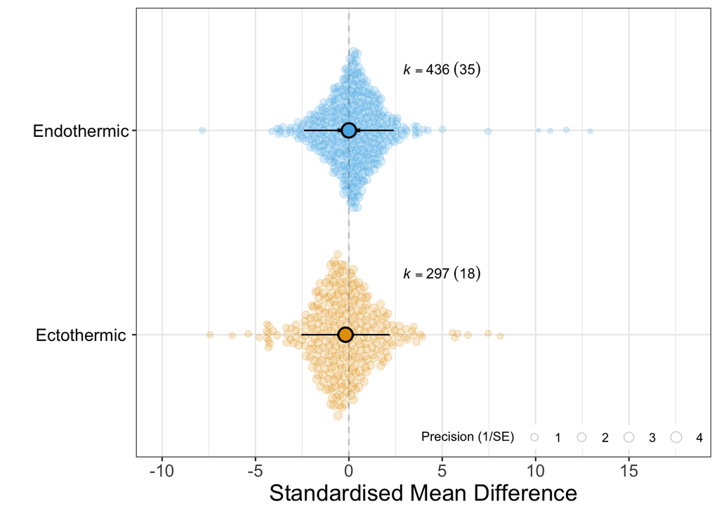

```r
thermo_plot <- orchard_plot(
  object = model_SMD_thermoregulation,
  mod = 'Thermoregulation',
  group = 'StudyID',
  k.pos = 5,
  trunk.size = 1,
  alpha = 0.2,
  cb = FALSE,
  xlab = "Standardised Mean Difference",
  transfm = "none"
) +
  scale_fill_okabe_ito() +
  scale_color_okabe_ito() +
  theme(
    axis.text = element_text(size = 12),
    axis.text.y = element_text(size = 12, angle = 0),
    axis.title = element_text(size = 16)
  ) +
  scale_y_continuous(
    limits = c(-10, 18),
    breaks = seq(-10, 15, 5),
    label = seq(-10, 15, 5)
  )


ggsave(
  filename = here(
    "./03_plots/01_hibernation/03a_thermoregulation_plot_OS.png"
  ),
  plot = thermo_plot,
  device = "png",
  height = 120,
  width = 185,
  units = "mm"
)

ggsave(
  filename = here(
    "./03_plots/01_hibernation/03a_thermoregulation_plot_OS.pdf"
  ),
  plot = thermo_plot,
  height = 120,
  width = 185,
  units = "mm"
)

thermo_plot
```

## Endotherms vs. ectotherms:

Now, we investigate if the response to hibernation varies across biomarkers of oxidative stress for endotherms and ectotherms. We include four markers:

```r
table(df_SMD$Biomarker_cat_2)
```

```
##
##      Antioxidant Oxidative_damage       Regulatory              ROS
##              582              102               34               24
```

### Meta-model for endotherms:

```r
## data for SMD
df_SMD_endo <- df_SMD %>%
  filter(!is.na(SMDH)) %>%
  filter(!is.na(SMDH.sv)) %>%
  filter(Thermoregulation == 'Endothermic')

## calculate var-cover matrix to control for correlated effect sizes within study and tissue
V_endo <- vcalc(
  vi = SMDH.sv,
  cluster = StudyID,
  subgroup = Tissue,
  grp1 = Hib_M,
  grp2 = Euthermia_M,
  w1 = Hib_N,
  w2 = Euthermia_N,
  data = df_SMD_endo
)
```

- Number of observation with non-missing SMD: 443
- Number of studies in the dataset for analysis: 35
- Number of species in the dataset for analysis: 13

```r
model_SMD_endo <- rma.mv(
  yi = SMDH,
  V = V_endo,
  mods = ~ Biomarker_cat_2 - 1,
  random = list(
    ~ 1 | scientific_name_phylo,
    ~ 1 | Species,
    ~ 1 | obsID,
    ~ 1 | StudyID
  ),
  data = df_SMD_endo,
  R = list(scientific_name_phylo = phylo_cor),
  method = "REML",
  control = list(optimizer = "BFGS"),
  verbose = F
)
```

```r
saveRDS(
  object = model_SMD_endo,
  file = here(
    './04_models/01_hibernation/04a_metareg_hibernation_endo_OS.RDS'
  )
)
model_SMD_endo <- readRDS(
  file = here(
    './04_models/01_hibernation/04a_metareg_hibernation_endo_OS.RDS'
  )
)
summary(model_SMD_endo)
```

```
##
## Multivariate Meta-Analysis Model (k = 436; method: REML)
##
##    logLik   Deviance        AIC        BIC       AICc
## -736.3607  1472.7214  1488.7214  1521.2688  1489.0618
##
## Variance Components:
##
##             estim    sqrt  nlvls  fixed                 factor    R
## sigma^2.1  0.0000  0.0004     13     no  scientific_name_phylo  yes
## sigma^2.2  0.0886  0.2977     13     no                Species   no
## sigma^2.3  0.7391  0.8597    436     no                  obsID   no
## sigma^2.4  0.0000  0.0015     35     no                StudyID   no
##
## Test for Residual Heterogeneity:
## QE(df = 432) = 1265.6470, p-val < .0001
##
## Test of Moderators (coefficients 1:4):
## QM(df = 4) = 13.5736, p-val = 0.0088
##
## Model Results:
##
##                                  estimate      se     zval    pval    ci.lb
## Biomarker_cat_2Antioxidant        -0.0931  0.1251  -0.7444  0.4566  -0.3384
## Biomarker_cat_2Oxidative_damage   -0.4466  0.2063  -2.1651  0.0304  -0.8509
## Biomarker_cat_2Regulatory          0.4995  0.2558   1.9526  0.0509  -0.0019
## Biomarker_cat_2ROS                -0.4442  0.2514  -1.7666  0.0773  -0.9369
##                                    ci.ub
## Biomarker_cat_2Antioxidant        0.1521
## Biomarker_cat_2Oxidative_damage  -0.0423  *
## Biomarker_cat_2Regulatory         1.0009  .
## Biomarker_cat_2ROS                0.0486  .
##
## ---
## Signif. codes:  0 '***' 0.001 '**' 0.01 '*' 0.05 '.' 0.1 ' ' 1
```

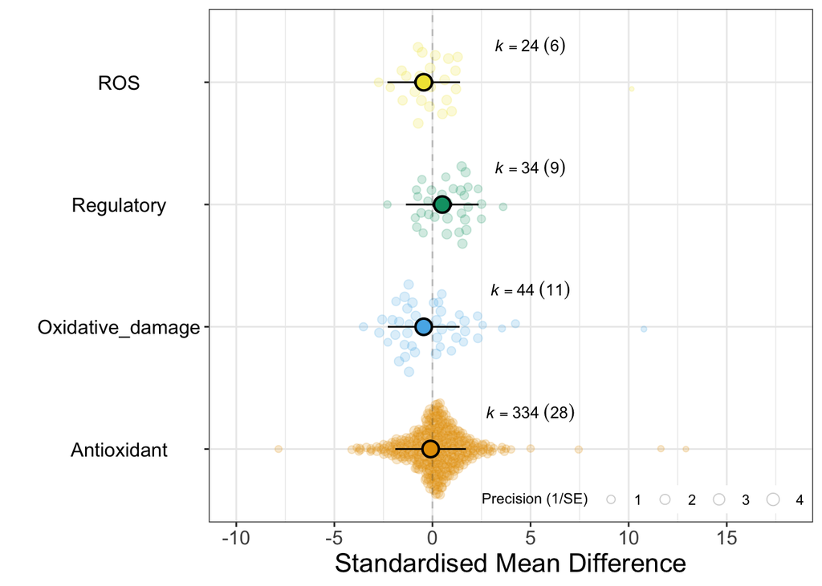

```r
endo_plot <- orchard_plot(
  object = model_SMD_endo,
  mod = 'Biomarker_cat_2',
  group = 'StudyID',
  k.pos = 5,
  trunk.size = 1,
  alpha = 0.2,
  cb = FALSE,
  xlab = "Standardised Mean Difference",
  transfm = "none"
) +
  scale_fill_okabe_ito() +
  scale_color_okabe_ito() +
  theme(
    axis.text = element_text(size = 12),
    axis.text.y = element_text(size = 12, angle = 0),
    axis.title = element_text(size = 16)
  ) +
  scale_y_continuous(
    limits = c(-10, 18),
    breaks = seq(-10, 15, 5),
    label = seq(-10, 15, 5)
  )

ggsave(
  filename = here(
    "./03_plots/01_hibernation/04a_endo_plot_OS.png"
  ),
  plot = endo_plot,
  device = "png",
  height = 120,
  width = 185,
  units = "mm"
)

ggsave(
  filename = here(
    "./03_plots/01_hibernation/04a_endo_plot_OS.pdf"
  ),
  plot = endo_plot,
  height = 120,
  width = 185,
  units = "mm"
)

endo_plot
```

### Meta-model for ectotherms:

```r
## data for SMD
df_SMD_ecto <- df_SMD %>%
  filter(!is.na(SMDH)) %>%
  filter(!is.na(SMDH.sv)) %>%
  filter(Thermoregulation == 'Ectothermic')

## calculate var-cover matrix to control for correlated effect sizes within study and tissue
V_ecto <- vcalc(
  vi = SMDH.sv,
  cluster = StudyID,
  subgroup = Tissue,
  grp1 = Hib_M,
  grp2 = Euthermia_M,
  w1 = Hib_N,
  w2 = Euthermia_N,
  data = df_SMD_ecto
)
```

- Number of observation with non-missing SMD: 299
- Number of studies in the dataset for analysis: 18
- Number of species in the dataset for analysis: 13

```r
model_SMD_ecto <- rma.mv(
  yi = SMDH,
  V = V_ecto,
  mods = ~ Biomarker_cat_2 - 1,
  random = list(
    ~ 1 | StudyID,
    ~ 1 | scientific_name_phylo,
    ~ 1 | Species,
    ~ 1 | obsID
  ),
  data = df_SMD_ecto,
  R = list(scientific_name_phylo = phylo_cor),
  method = "REML"
)
```

```r
saveRDS(
  object = model_SMD_ecto,
  file = here(
    './04_models/01_hibernation/05a_metareg_ecto_hibernation_OS.RDS'
  )
)
model_SMD_ecto <- readRDS(
  file = here(
    './04_models/01_hibernation/05a_metareg_ecto_hibernation_OS.RDS'
  )
)
summary(model_SMD_ecto)
```

```
##
## Multivariate Meta-Analysis Model (k = 297; method: REML)
##
##    logLik   Deviance        AIC        BIC       AICc
## -570.6383  1141.2766  1153.2766  1175.3985  1153.5683
##
## Variance Components:
##
##             estim    sqrt  nlvls  fixed                 factor    R
## sigma^2.1  0.0000  0.0001     18     no                StudyID   no
## sigma^2.2  0.1325  0.3640     13     no  scientific_name_phylo  yes
## sigma^2.3  0.2444  0.4944     13     no                Species   no
## sigma^2.4  1.5759  1.2553    297     no                  obsID   no
##
## Test for Residual Heterogeneity:
## QE(df = 295) = 1294.7641, p-val < .0001
##
## Test of Moderators (coefficients 1:2):
## QM(df = 2) = 25.9707, p-val < .0001
##
## Model Results:
##
##                                  estimate      se     zval    pval    ci.lb
## Biomarker_cat_2Antioxidant        -0.3943  0.2668  -1.4776  0.1395  -0.9172
## Biomarker_cat_2Oxidative_damage    0.7122  0.3184   2.2363  0.0253   0.0880
##                                   ci.ub
## Biomarker_cat_2Antioxidant       0.1287
## Biomarker_cat_2Oxidative_damage  1.3363  *
##
## ---
## Signif. codes:  0 '***' 0.001 '**' 0.01 '*' 0.05 '.' 0.1 ' ' 1
```

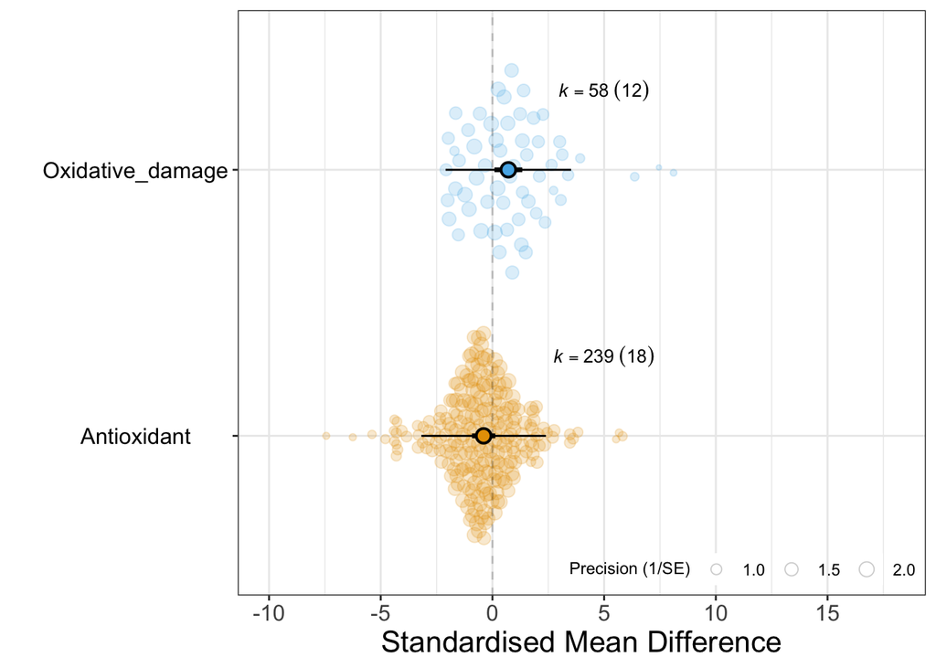

```r
ecto_plot <- orchard_plot(
  object = model_SMD_ecto,
  mod = 'Biomarker_cat_2',
  group = 'StudyID',
  k.pos = 5,
  trunk.size = 0.75,
  alpha = 0.2,
  cb = FALSE,
  xlab = "Standardised Mean Difference",
  transfm = "none"
) +
  scale_fill_okabe_ito() +
  scale_color_okabe_ito() +
  theme(
    axis.text = element_text(size = 12),
    axis.text.y = element_text(size = 12, angle = 0),
    axis.title = element_text(size = 16)
  ) +
  scale_y_continuous(
    limits = c(-10, 18),
    breaks = seq(-10, 15, 5),
    label = seq(-10, 15, 5)
  )

ggsave(
  filename = here(
    "./03_plots/01_hibernation/05a_ecto_plot_OS.png"
  ),
  plot = ecto_plot,
  device = "png",
  height = 120,
  width = 185,
  units = "mm"
)

ggsave(
  filename = here(
    "./03_plots/01_hibernation/05a_ecto_plot_OS.pdf"
  ),
  plot = ecto_plot,
  height = 120,
  width = 185,
  units = "mm"
)

ecto_plot
```